# Lista 1 – GED-17

Arthur Stevenson

2022-06-07

## Questão 1 – Alisamento Exponencial Simples

Inicialmente, tomam-se os dados referentes a produção de veículos no Brasil, fornecidos pelo site G1, e é criada uma série temporal utilizando-os. O gráfico dessa série temporal é gerado a seguir.

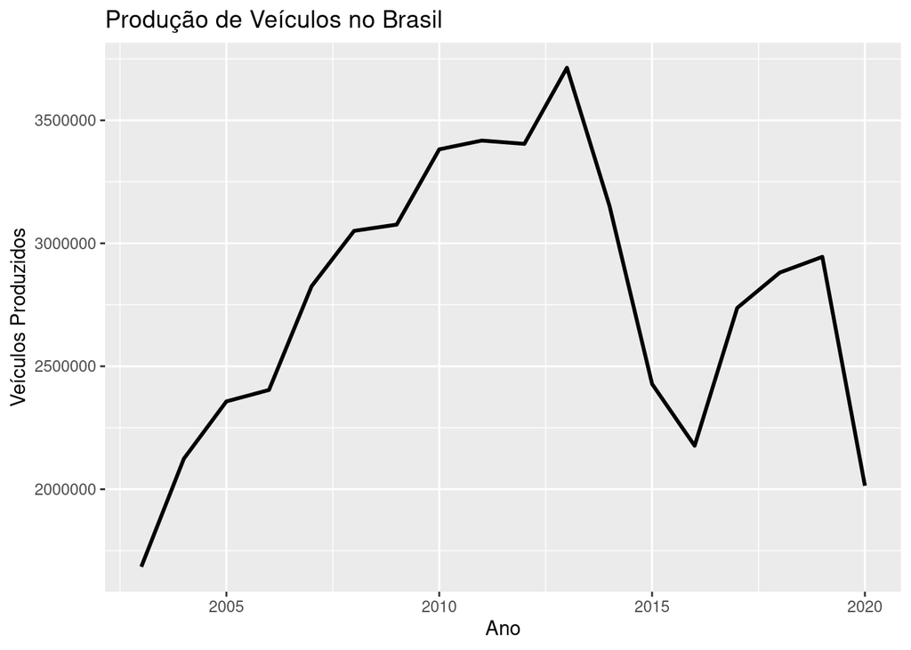

A seguir, tem-se a previsão, com base nos valores de 2003 a 2019, da quantidade de veículos produzidos no Brasil para os anos de 2020 a 2025.

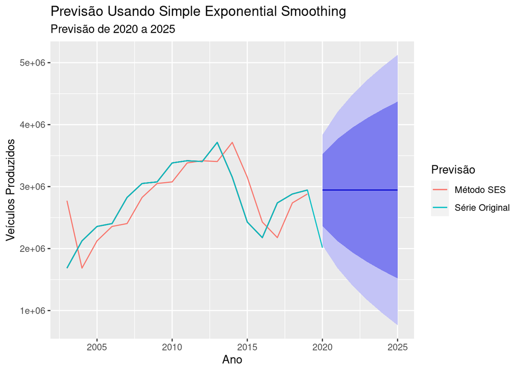

Em seguida, tem-se as previsões para os anos de 2021 a 2025, com base nos dados obtidos de 2003 a 2020.

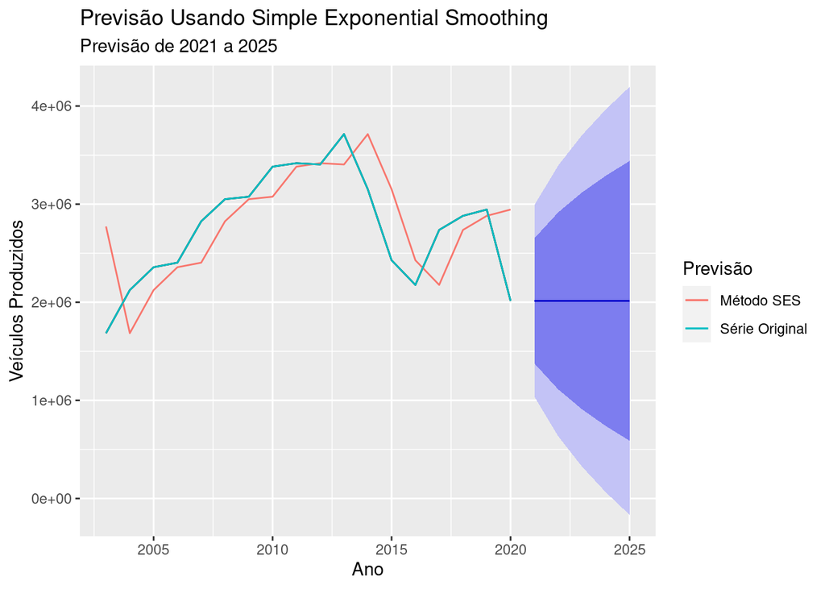

Comparando-se as duas previsões geradas, nota-se que a segunda tem valores significativamente menores que a primeira. Isso se deve ao número de veículos produzidos no ano de 2020, que foi significativamente menor que em 2019. Analisando-se o contexto global, bem como o artigo fornecido, constata-se que, devido ao fechamento das fábricas da multinacional Ford, houve uma redução significativa na quantidade máxima de veículos que poderiam ser produzidos no país. Isto, associado à pandemia de COVID-19, que paralisou diversos setores da economia, resultou em um número significativamente menor de veículos produzidos no ano de 2020, frente ao anterior.

Como no método de alisamento exponencial os valores mais recentes da série têm uma influência maior na previsão, naturalmente, espera-se que a série que contém os dados referentes ao ano de 2020 tenha previsões numericamente menores que a que vai até 2019.

## Questão 2 – Método de Holt

Primeiramente, tomam-se os dados referentes ao ativo RADL3, de 19 de Abril até 20 de Maio de 2022, e constrói-se uma série temporal com eles.

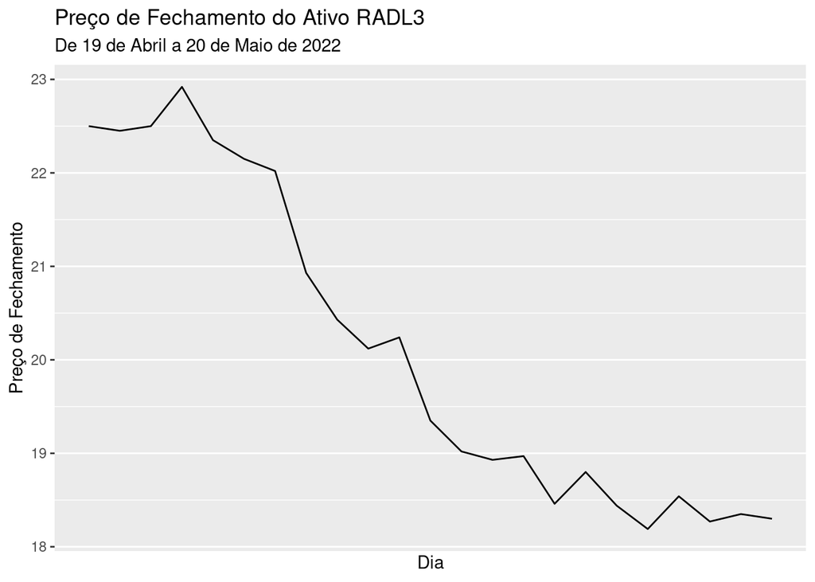

Em seguida, utilizando o método de Holt, faz-se uma previsão do valor do ativo para os próximos 5 dias.

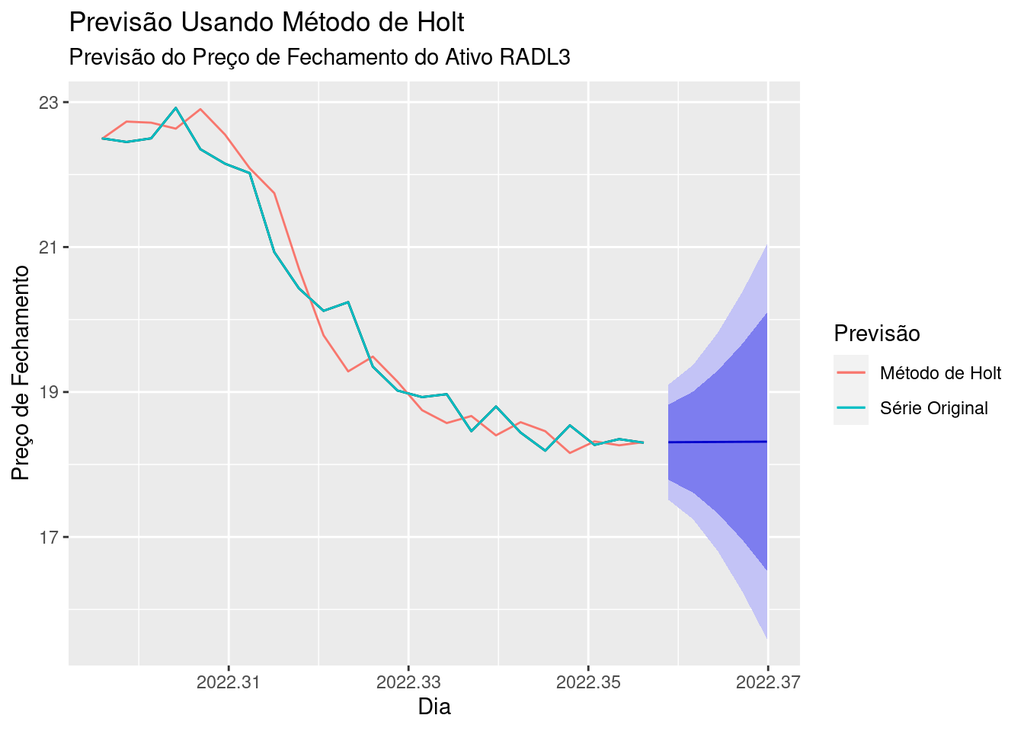

## Questão 3 – Método de Holt-Winters

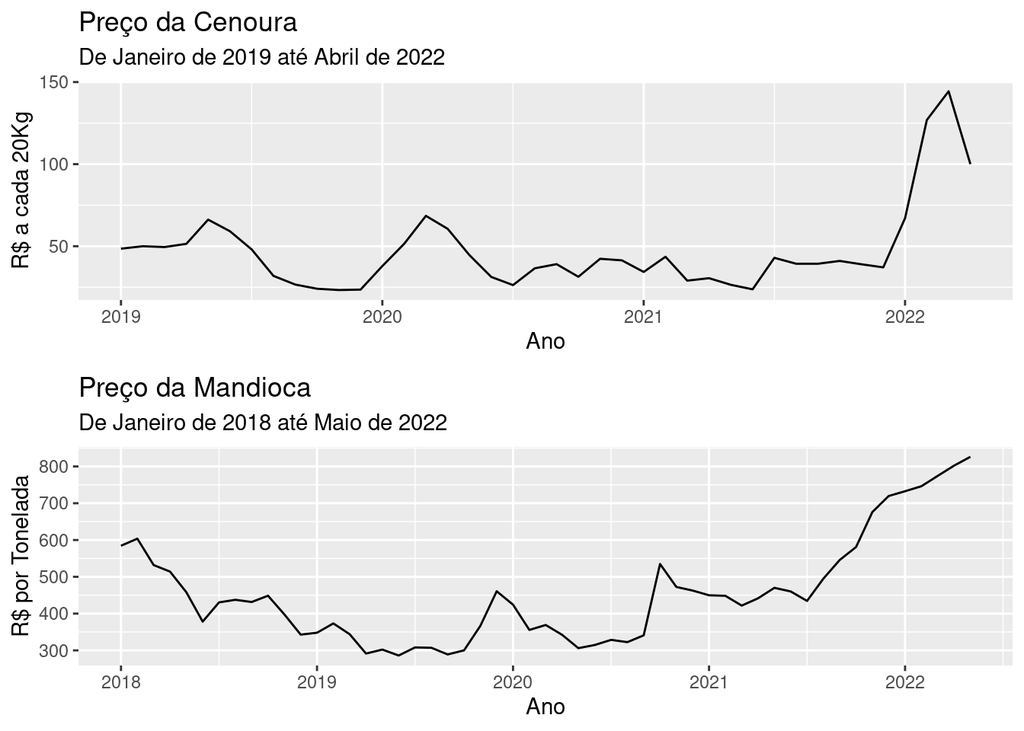

Assim, pode ser realizada a previsão dos preços de cada um dos produtos através do uso do Método de Holt-Winters. Entretanto, antes que a previsão seja realizada, é necessário escolher o modelo a ser utilizado, o aditivo ou multiplicativo. Dessa forma, será realizada primeiro a análise da cenoura.

```
## Holt-Winters' additive method
##
## Call:
##  hw(y = cenoura.ts, h = 5, seasonal = "additive")
##
##   Smoothing parameters:
##     alpha = 0.9999
##     beta  = 1e-04
##     gamma = 1e-04
##
##   Initial states:
##     l = 45.4429
##     b = 0.9099
##     s = -2.6093 -1.6442 -12.4075 -6.9039 -3.2422 -1.6608
##            -9.4001 -0.5506 8.5047 17.1729 12.6511 0.09
##
##   sigma:  17.8273
##
##      AIC     AICc      BIC
## 391.5807 419.3989 420.2917
```

```
## Holt-Winters' multiplicative method
##
## Call:
##  hw(y = cenoura.ts, h = 5, seasonal = "multiplicative")
##
##   Smoothing parameters:
##     alpha = 0.9999
##     beta  = 0.133
##     gamma = 1e-04
##
##   Initial states:
##     l = 45.7517
##     b = -0.9989
##     s = 0.8068 0.8262 0.7348 0.7642 0.7453 0.8284
##            0.8796 1.1067 1.1649 1.6029 1.5255 1.0149
##
##   sigma:  0.3878
##
##      AIC     AICc      BIC
## 382.7342 410.5524 411.4451
```

Portanto, como temos um Critério de Informação de Akaike menor para o modelo multiplicativo, optamos por ele para realizar as previsões dos preços da cenoura. Assim, pode ser gerado o gráfico que contém as previsões, e a série original.

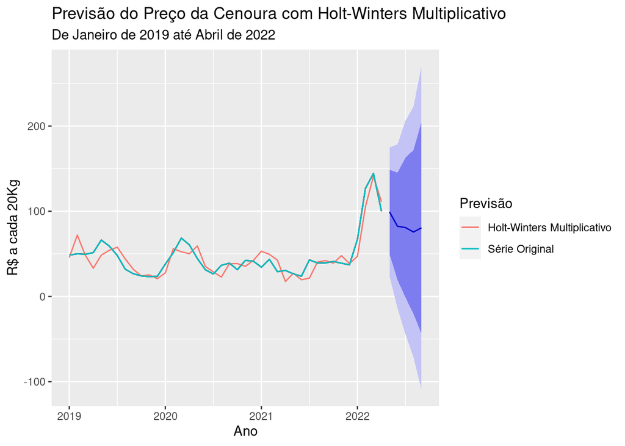

Feita a previsão da cenoura, pode ser realizado um processo análogo para a mandioca.

```
## Holt-Winters' additive method
##
## Call:
##  hw(y = mandioca.ts, h = 5, seasonal = "additive")
##
##   Smoothing parameters:
##     alpha = 0.8556
##     beta  = 0.0794
##     gamma = 2e-04
##
##   Initial states:
##     l = 543.8202
##     b = 1.675
##     s = 46.3808 42.5519 20.9714 -30.6241 -37.4881 -51.3225
##            -43.1461 -1.8093 -5.5641 17.081 22.7307 20.2383
##
##   sigma:  51.4266
##
##      AIC     AICc      BIC
## 643.0352 660.5209 676.5301
```

```
## Holt-Winters' multiplicative method
##
## Call:
##  hw(y = mandioca.ts, h = 5, seasonal = "multiplicative")
##
##   Smoothing parameters:
##     alpha = 0.5755
##     beta  = 0.1071
##     gamma = 2e-04
##
##   Initial states:
##     l = 534.9374
##     b = 0.6391
##     s = 1.1101 1.0831 1.0671 0.9387 0.9191 0.8855
##            0.8658 0.9598 0.9959 1.0232 1.0716 1.08
##
##   sigma:  0.1293
##
##      AIC     AICc      BIC
## 651.3070 668.7928 684.8020
```

Da mesma forma que antes, como o modelo aditivo possui um Critério de Informação de Akaike menor, ele é utilizado para realizar a previsão dos preços.

[figure not shown]

## Questão 4 – Componentes da Série Temporal

Utilizando o software R, podem ser gerados os gráficos para as três séries temporais fornecidas, da movimentação de passageiros por vias aéreas, ferroviárias, e por automóveis, respectivamente.

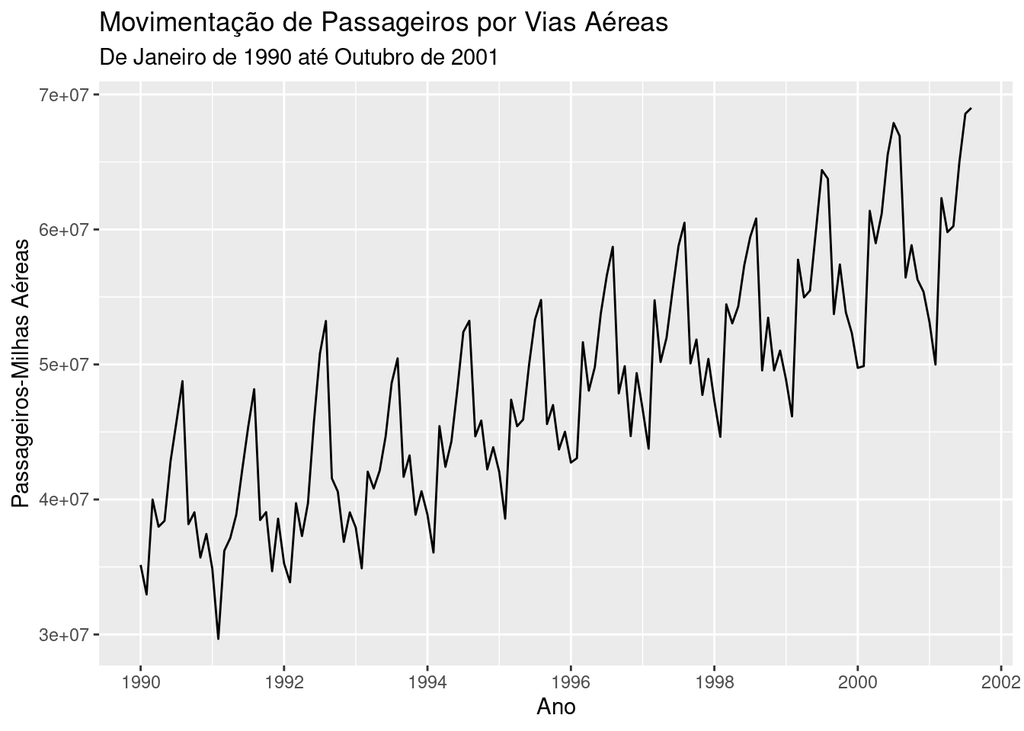

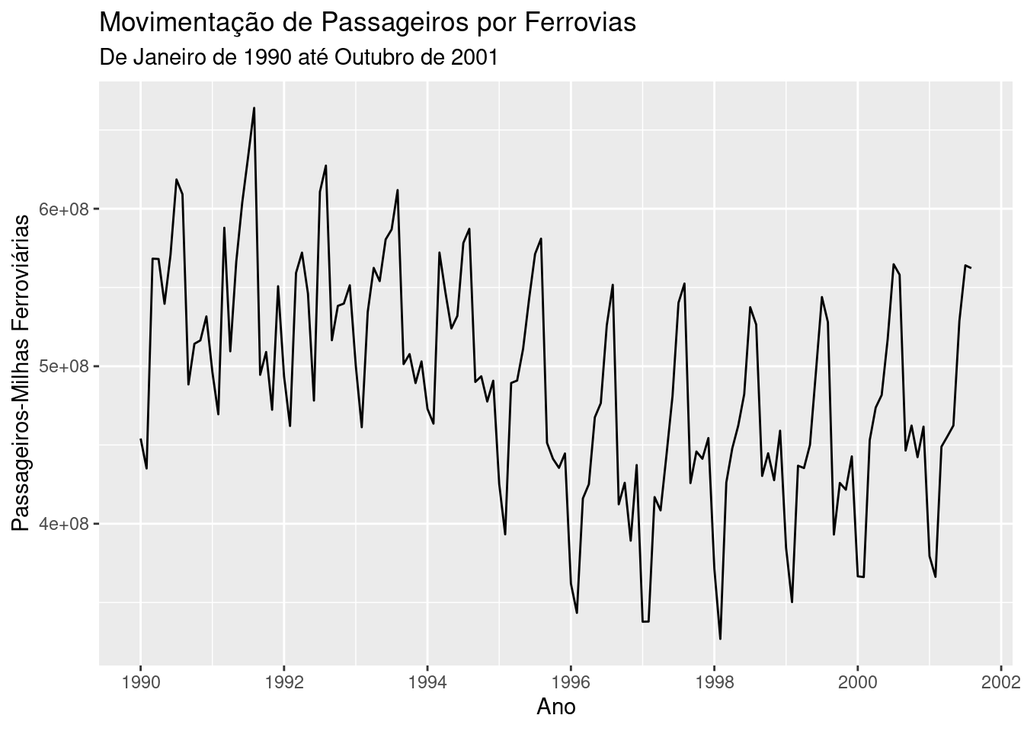

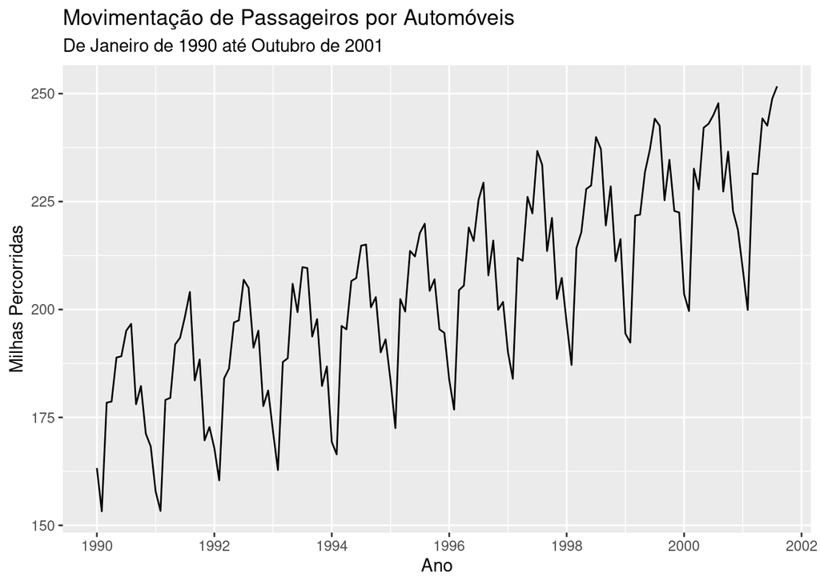

Analisando-se o gráfico referente à movimentação de passageiros por vias aéreas, isto é, o gráfico (a), nota-se uma clara tendência linear de crescimento, e um caráter repetitivo de crescimento, com um pico próximo da metade do ano. Como esse comportamento se repete a cada ano, considera-se que é um caráter sazonal, e não cíclico. Por fim, nota-se também um caráter aleatório nos valores do gráfico, dado que ele não é perfeitamente regular.

Portanto, o gráfico referente à serie temporal aérea possui as componentes de tendência, sazonalidade, e aleatória. Realizando uma análise análoga para os demais, constata-se que o de automóveis possui as mesmas características do primeiro, e, portanto, possui componentes de tendência, sazonalidade, e aleatória. Antes de determinar as características da série temporal ferroviária, serão gerados novos gráficos.

Assim, para realizar uma análise da tendência das séries, sem que haja tanta interferência da sazonalidade, pode-se utilizar um alisamento exponencial de Holt, com um pequeno valor de $\alpha$, nos dados obtidos. Assim, obtém-se os gráficos abaixo.

Por fim, analisando o gráfico da série temporal ferroviária, nota-se que, além do caráter aleatório e sazonal, a série temporal aparenta também ter um caráter cíclico, dado que a sua linha de tendência, indicada pelo alisamento realizado com o método de Holt, primeiro decresce e, em seguida, passa a crescer, de maneira similar a uma função seno.

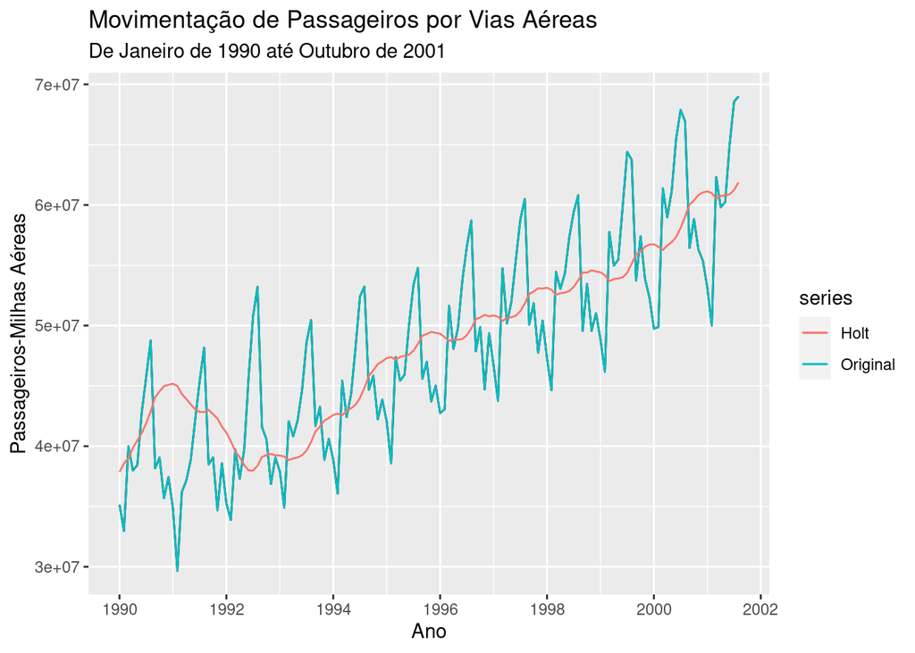

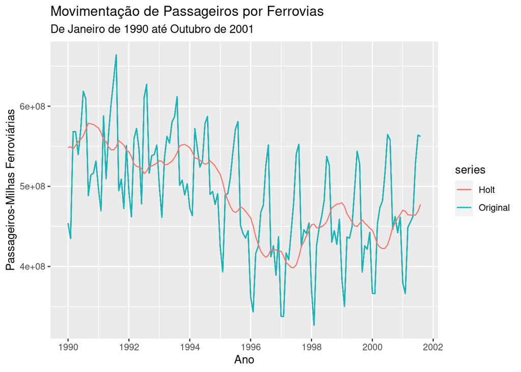

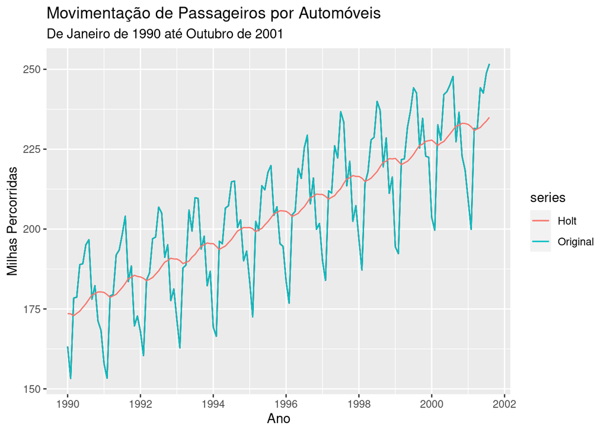

## Questão 5 – Alisamento Exponencial Simples

Inicialmente, para gerar um gráfico idêntico ao que foi mostrado no enunciado da questão, o conjunto de dados não pode ser plotado por inteiro, visto que a imagem original não contém todos os 100 pontos que são fornecidos. Assim, limitando a quantidade de pontos que são utilizados, pode-se obter a imagem análoga criada com o auxílio do R.

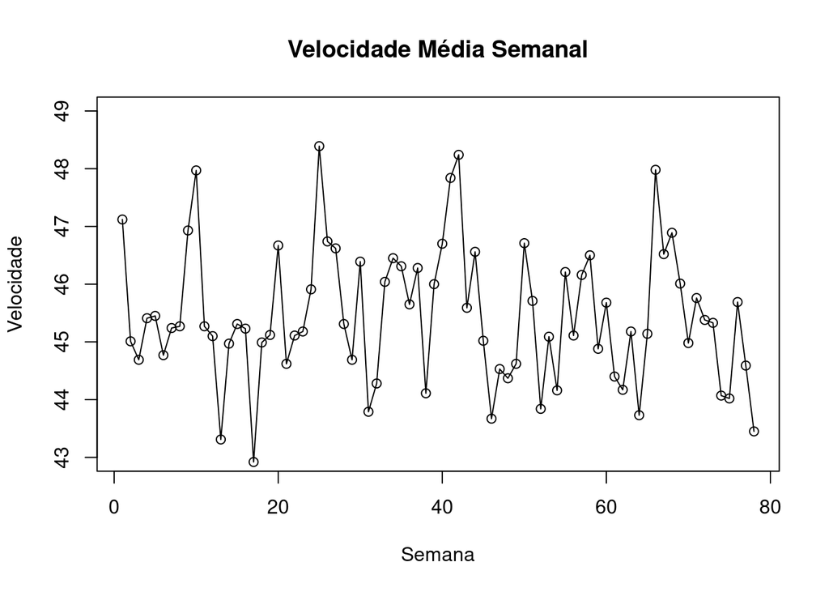

Em seguida, pode-se aplicar o Alisamento Exponencial Simples, com diferentes valores de alfa, no conjunto de dados. Nesse caso, serão considerados todos os valores de velocidade fornecidos. Assim, pode-se calular o valor do SSE para os diferentes valores de $\alpha$, e utilizar o próprio software R para buscar o melhor valor de $\alpha$, de acordo com a minimização do Critério de Informação de Akaike.

| Valor de Alfa | SSE |
| --- | --- |
| 0.1 | 140.790122954509 |
| 0.2 | 132.936816706671 |
| 0.3 | 130.500576645877 |
| 0.4 | 130.029502257703 |
| 0.5 | 130.78522036843 |
| 0.9 | 146.483011058195 |
| 0.2294 | Valor Encontrado pela Função SES |

Nota-se, então, que o valor de $\alpha$ encontrado através da minimização do Critério de Informação de Akaike é significativamente menor que o encontrado por Montgomery. Isso significa que os valores mais recentes têm menos influência nos valores encontrados no ajuste.

Com o trecho da série utilizada pelo autor do livro, pode-se reconstruir a figura que contém a previsão dos valores de velocidade subsequentes através da técnica de Alisamento Exponencial Simples.

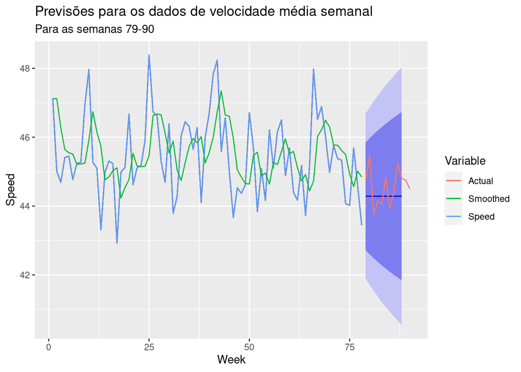

## Questão 6

Com base na descrição do método de Simple Exponential Smoothing, pode-se replicá-lo utilizando os comandos fornecidos no R e, em seguida, gerar os gráficos que foram apresentados durante o enunciado da questão.

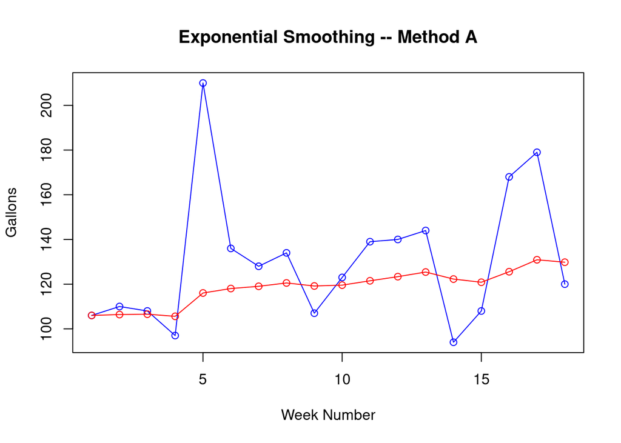

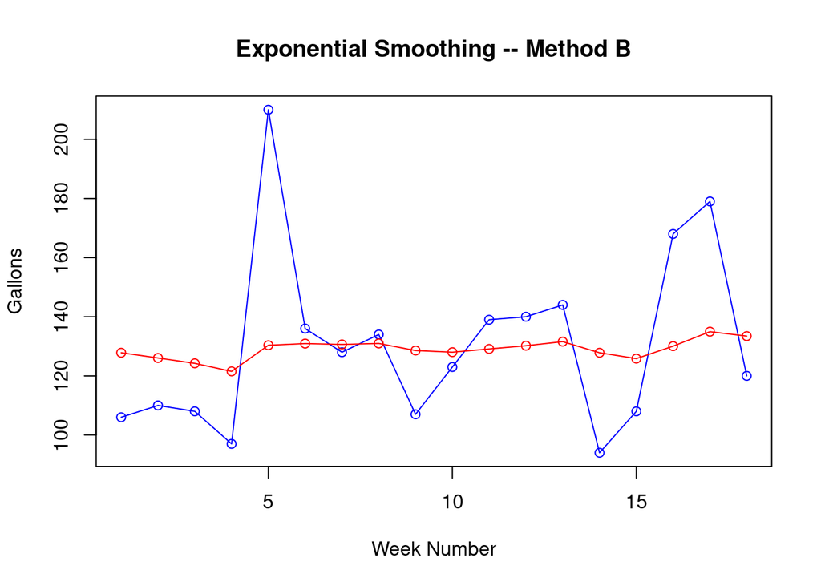

Ademais, podem ser realizadas as previsões para a semana 19 de ambos os métodos.

```
## [1] "Previsão do Primeiro Método" "128.835369653125"
```

```
## [1] "Previsão do Segundo Método" "132.11243585711"
```

Em seguida, a implementação de SES presente no pacote Forecast do R pode ser utilizada para realizar a previsão, com dois valores diferentes da alfa, o utilizado pela empresa, e o considerado ótimo, através da minimização do Critério de Informação de Akaike.

```
## [1] "Modelo com alpha = 0.1"
```

```
## Time Series:
## Start = 1
## End = 18
## Frequency = 1
##  [1] 106.0000 106.0000 106.4000 106.5600 105.6040 116.0436 118.0392 119.0353
##  [9] 120.5318 119.1786 119.5607 121.5047 123.3542 125.4188 122.2769 120.8492
## [17] 125.5643 130.9079
```

```
## [1] "Modelo Ótimo"
```

```
## Time Series:
## Start = 1
## End = 18
## Frequency = 1
##  [1] 130.6121 130.6096 130.6075 130.6053 130.6019 130.6099 130.6104 130.6101
##  [9] 130.6105 130.6081 130.6074 130.6082 130.6091 130.6105 130.6068 130.6046
## [17] 130.6083 130.6131
```

Portanto, comparando-se os dados obtidos com a tabela fornecida, nota-se que o ajuste automático de $\alpha$ realizado pelo R estabeleceu uma quantidade de galões praticamente constante, enquanto o método com $\alpha = 0.1$ tem valores iguais aos da coluna referente ao método A.^

## Questão 7

Inicialmente, será utilizada a Ponderação Exponencial Simples, com diferentes valores de alfa, para realizar o alisamento da série temporal referente às vendas. Para o mês de janeiro do ano seguinte, tem-se as previsões com os diferentes valores a seguir.

Ponderação Exponencial Simples usando Alpha = 0.1

```
##    Point Forecast    Lo 80    Hi 80   Lo 95    Hi 95
## 13       6.043192 5.676418 6.409966 5.48226 6.604124
```

Ponderação Exponencial Simples usando Alpha = 0.5

```
##    Point Forecast    Lo 80    Hi 80    Lo 95    Hi 95
## 13       6.204082 5.809106 6.599058 5.600019 6.808145
```

Ponderação Exponencial Simples usando Alpha = 0.9

```
##    Point Forecast    Lo 80    Hi 80   Lo 95    Hi 95
## 13       6.278766 5.827118 6.730413 5.58803 6.969501
```

Assim, com as três séries ajustadas utilizando a ponderação exponencial simples, pode-se preencher a tabela apresentada, e gerar o gráfico para compará-las. Para o último, a série original está apresentada em preto.

[output not shown]

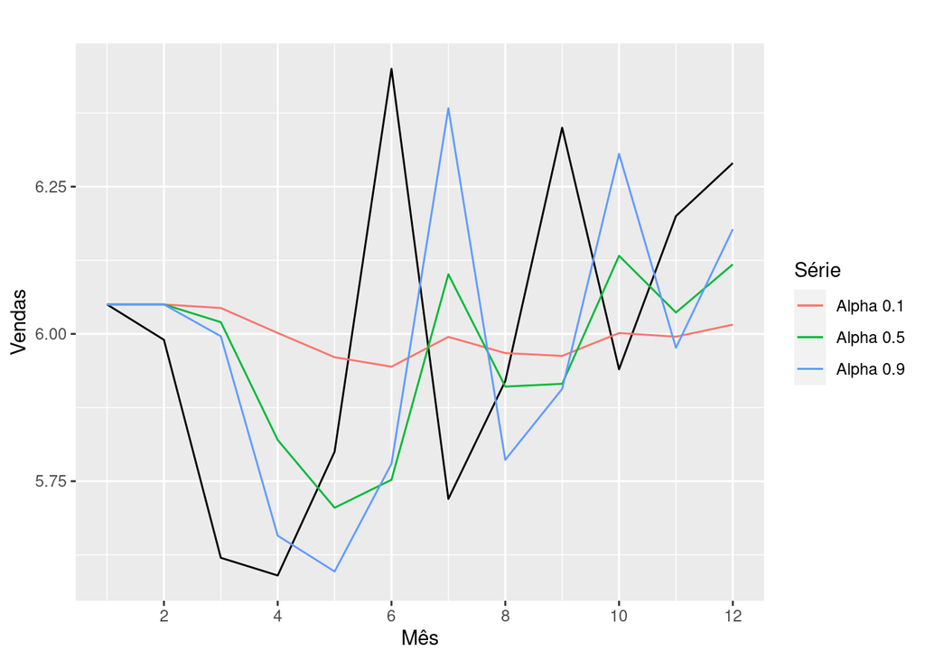

Em seguida, pode ser utilizado o Método de Holt para realizar o alisamento da série temporal. Primeiramente, o valor de janeiro do ano inicial ajustado por Holt, com coeficientes Alpha = 0.2 e Beta = 0.5, é dado por:

```
## [1] 5.99
```

Assim, em posse destes ajustes e previsões, podem ser calculados alguns dos critérios de avaliação das séries temporais criadas. Isto é feito utilizando-se o comando `accuracy()` do R. Para a obtenção do MSE, basta tomar $\text{RMSE}^2$, isto é, elevar o valor de RMSE ao quadrado.

```
##                        ME     RMSE       MAE        MPE     MAPE      MASE
## Training set -0.005673247 0.286195 0.2343101 -0.3099426 3.909814 0.7492476
##                    ACF1
## Training set 0.05935216
```

```
##                      ME      RMSE       MAE      MPE     MAPE      MASE
## Training set 0.02568034 0.3082013 0.2363314 0.223775 3.914138 0.7557108
##                    ACF1
## Training set -0.1734379
```

```
##                      ME      RMSE       MAE       MPE     MAPE      MASE
## Training set 0.02118201 0.3524225 0.2765538 0.1566378 4.597912 0.8843289
##                    ACF1
## Training set -0.3538408
```

```
##                     ME      RMSE       MAE      MPE     MAPE      MASE
## Training set 0.1293003 0.3229427 0.2231091 1.975692 3.637672 0.7134304
##                     ACF1
## Training set -0.01371442
```

A seguir, pode ser realizada a previsão do valor de vendas para Janeiro do ano seguinte com o método anterior. Com esse valor, pode ser construído um gráfico contendo a série original, a série com o alisamento usando o Método de Holt, e a previsão realizada.

```
##    Point Forecast    Lo 80    Hi 80    Lo 95    Hi 95
## 13       6.279181 5.865314 6.693049 5.646225 6.912137
```

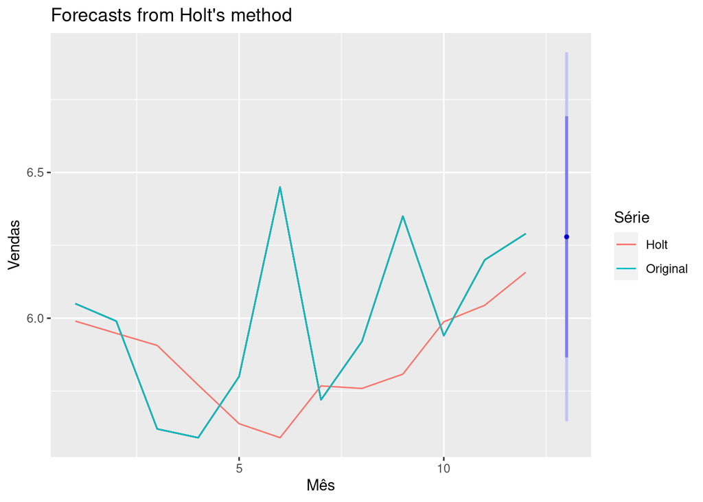

Após essa análise inicial, pode ser utilizada a própria função Holt, presente na biblioteca Forecast do R, para determinar os valores ótimos de $\alpha$ e $\beta$, considerando a minimização do Critério de Informação de Akaike.

```
## Holt's method
##
## Call:
##  holt(y = vendas.ts, h = 1, initial = "optimal")
##
##   Smoothing parameters:
##     alpha = 1e-04
##     beta  = 1e-04
##
##   Initial states:
##     l = 5.7749
##     b = 0.0339
##
##   sigma:  0.2981
##
##       AIC      AICc       BIC
##  5.904376 15.904376  8.328909
```

Analisando a solução do aluno de MBA, constata-se que, para a ponderação exponencial simples, foram trocadas as posições de $\hat{y}_{t-1}$ e $y_t$, o que prejudicou o alisamento realizado, e teve um efeito cascata, que tornou a sua solução inválida.

## Questão 8

Inicialmente, tomando o código fornecido, bem como os dados da Amtrak, pode-se reproduzir a figura apresentada.

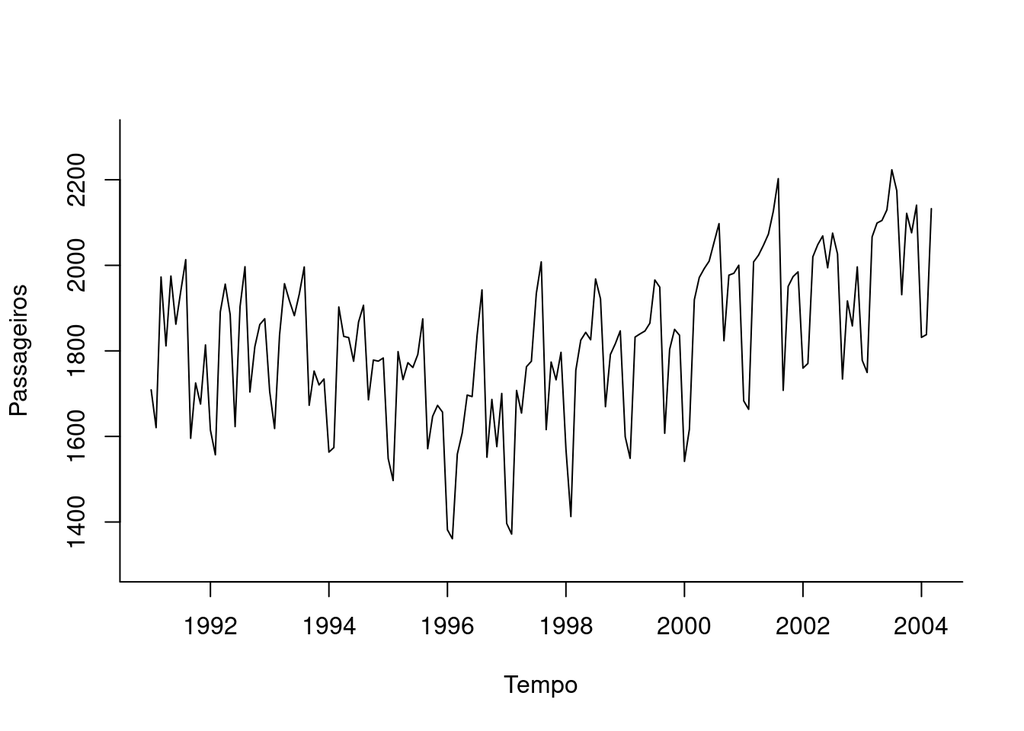

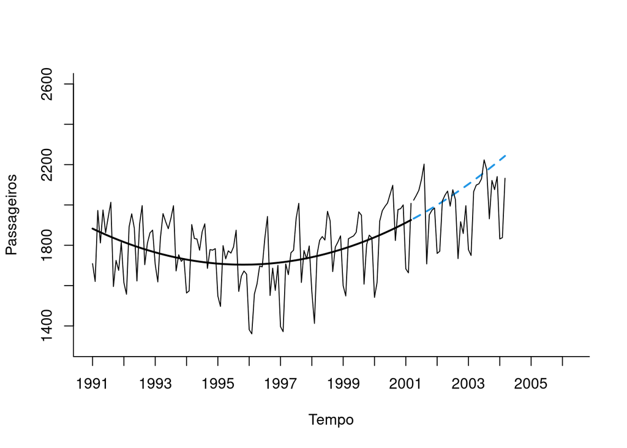

Assim, podem ser analisados os vetores especificados nas questões. Primeiramente, o vetor `passageiros.lm.pred$residuals` corresponde aos resíduos da série temporal ajustada com a função `forecast()`, que são a diferença entre os valores da série temporal ajustada e a original.

Em seguida, `valid.ts - passageiros.lm.pred$mean` é, novamente, um vetor que contém a diferença entre os valores da série original e os valores da série temporal que foi criada com a função `forecast()`. Nesse caso, entretanto, os valores são referentes não ao intervalo de tempo que foi ajustado, como no caso anterior, mas ao intervalo de tempo correspondente à previsão.

Portanto, o primeiro comando fornece as diferenças no intervalo de treinamento, e o segundo, no de validação. A média e desvio padrão do vetor que concatena os dois vetores anteriores é dada abaixo.

```
## [1] "Média do Vetor de Erro:" "-19.0102819734351"
```

```
## [1] "Desvio-Padrão do Vetor de Erro:" "154.348751929338"
```

Por fim, pode ser realizado um teste de normalidade no vetor de erro, bem como a confecção do seu gráfico. Ambos estão abaixo. O teste escolhido foi o de Kolmogorov-Smirnov. Observando-se o p-valor encontrado, nota-se que ele é superior a 5% ($p_{val} = 0.1709$), de forma que a hipótese de que os valores do erro seguem uma distribuição normal não pode ser excluída. Assim, conclui-se que a previsão realizada possui uma boa precisão, dado que os seus valores são próximos do que normalmente se esperaria (como o erro aparenta ter uma distribuição normal, todos os valores do vetor são próximos do que se encontraria na natureza).

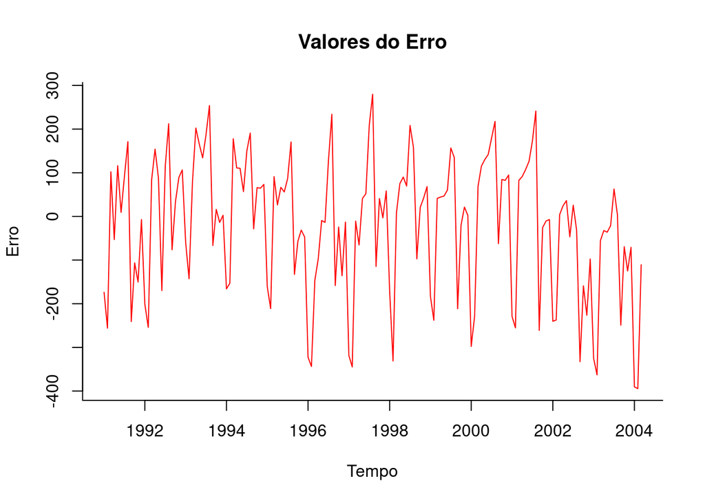

```
##
##  Asymptotic one-sample Kolmogorov-Smirnov test
##
## data:  z.erro
## D = 0.087936, p-value = 0.1709
## alternative hypothesis: two-sided
```

## Questão 9

Utilizando o R, é possível tomar os dados fornecidos, e realizar um ajuste usando o método de Holt-Winters para os valores. Assim, utilizando o comando `hw()`, e os valores de $\alpha$, $\beta$ e $\gamma$ especificados na figura, pode ser obtido o gráfico abaixo, que contém a série original, a ajustada por Holt-Winters, e a previsão para os próximos 4 trimestres.

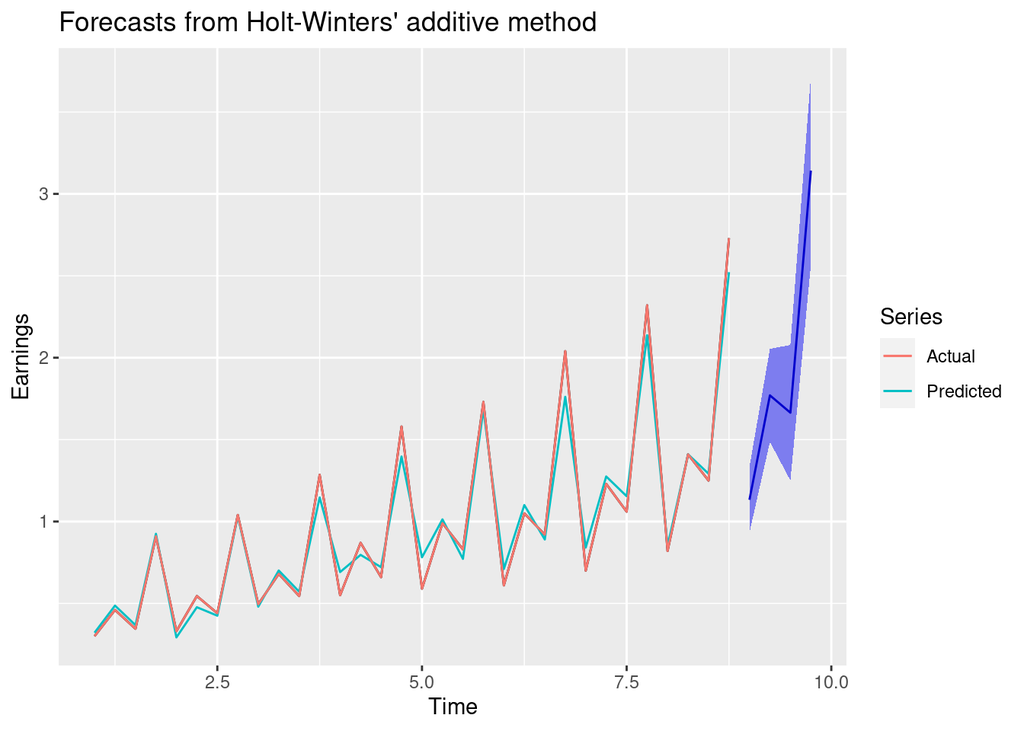

Em seguida, podem ser calculados os valores de MAPE, MAD, e MSD, fazendo uso do próprio R.

```
## [1] "MAPE: "           "8.23645095626762"
```

[output not shown]

[output not shown]

Pode-se, ainda, obter alguns outros valores associados ao modelo criado.

```
##                ME RMSE  MAE   MPE MAPE MASE  ACF1
## Training set 0.01  0.1 0.07 -1.75 8.24  0.5 -0.38
```

Em seguida, pode-se utilizar as otimizações de parâmetros implementadas na função `hw()` do R para encontrar os valores dos parâmetros considerados ótimos por ela. Para os modelos aditivo e multiplicativo, tem-se o seguinte.

```
## Holt-Winters' additive method
##
## Call:
##  hw(y = ganhos.ts, h = 4, seasonal = "additive", level = 0.95,
##
##  Call:
##      initial = "optimal")
##
##   Smoothing parameters:
##     alpha = 0.0176
##     beta  = 0.0176
##     gamma = 0.9824
##
##   Initial states:
##     l = 0.6004
##     b = 0.0128
##     s = 0.6857 -0.2257 -0.1214 -0.3386
##
##   sigma:  0.1487
##
##       AIC      AICc       BIC
## -2.273985  5.907833 10.917638
```

```
## Holt-Winters' multiplicative method
##
## Call:
##  hw(y = ganhos.ts, h = 4, seasonal = "multiplicative", level = 0.95,
##
##  Call:
##      initial = "optimal")
##
##   Smoothing parameters:
##     alpha = 0.1979
##     beta  = 0.0301
##     gamma = 1e-04
##
##   Initial states:
##     l = 0.4245
##     b = 0.0221
##     s = 1.6985 0.7759 0.9504 0.5751
##
##   sigma:  0.1038
##
##       AIC      AICc       BIC
## -38.05497 -29.87315 -24.86334
```

Assim, tem-se os parâmetros para cada um dos métodos agrupados na tabela abaixo.

| Aditivo | Multiplicativo |
| --- | --- |
| alpha = 0.0176 | alpha = 0.1979 |
| beta = 0.0176 | beta = 0.0301 |
| gamma = 0.9824 | gamma = 1e-04 |

Tem-se ainda o seguinte para o modelo multiplicativo.

```
##                ME RMSE  MAE  MPE MAPE MASE ACF1
## Training set 0.02 0.05 0.04 1.96 5.07 0.25 0.24
```

```
##        Qtr1      Qtr2      Qtr3      Qtr4
## 1 0.2568885 0.4617958 0.3955723 0.8820029
## 2 0.3136826 0.5462447 0.4640907 1.0441211
## 3 0.3663160 0.6753746 0.5750100 1.2939655
## 4 0.4538070 0.8129715 0.7000801 1.5721121
## 5 0.5522585 0.9587824 0.8161333 1.8557352
## 6 0.6400860 1.0795651 0.9016506 2.0380261
## 7 0.7093616 1.2001726 1.0106377 2.2941279
## 8 0.7993155 1.3628313 1.1500671 2.6329958
```

E, para o modelo aditivo, tem-se a saída de `modelo$fitted`.

```
##        Qtr1      Qtr2      Qtr3      Qtr4
## 1 0.2745965 0.5054840 0.4128708 1.3342491
## 2 0.3313247 0.4826368 0.3623542 0.9311528
## 3 0.3574338 0.5805397 0.4833594 1.0896862
## 4 0.5543742 0.7437325 0.6165197 1.3601870
## 5 0.6358872 0.9588990 0.7530452 1.6754881
## 6 0.6892999 1.0888235 0.9270248 1.8247039
## 7 0.7114598 1.1547144 1.0309376 2.1530790
## 8 0.8207733 1.3541875 1.1890650 2.4521714
```

Por fim, tem-se a versão da figura 2 com o ajuste ótimo do Método Multiplicativo, com o intervalo de confiança de 95%.

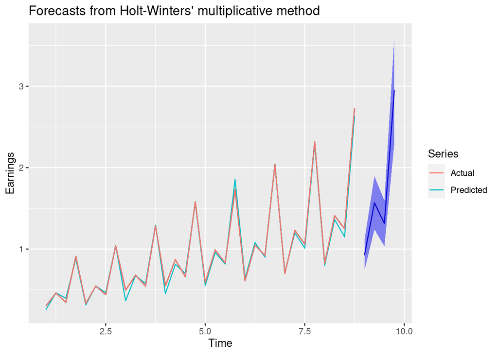

## Questão 10

Primeiramente, analisando a expressão fornecida para as células do Excel, constata-se que esse é um método de Holt-Winters Multiplicativo, dado que a Sazonalidade é um termo multiplicativo, e não aditivo.

Assim, para determinar o ajuste utilizando o método de Holt-Winters com o R, basta utilizar os dados fornecidos, bem como a opção `initial = "simple"`. Portanto, utilizando $\alpha=0.05$ $\beta=1$ e $\gamma=1$, obtém-se o gráfico abaixo. Para que ele fosse semelhante ao gráfico apresentado, o primeiro ano foi cortado da representação.

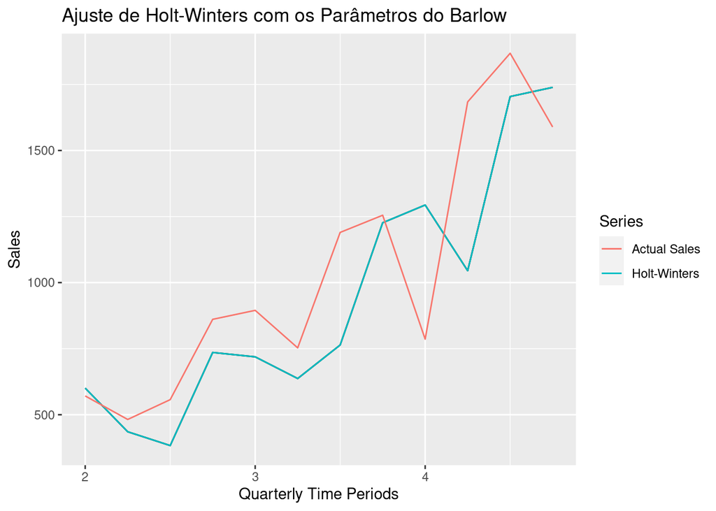

Com o modelo criado, pode-se calcular o seu MSE, o que é feito a seguir.

```
##                ME   RMSE    MAE  MPE  MAPE MASE  ACF1
## Training set 51.9 254.76 185.01 0.87 21.04 0.51 -0.15
```

Percebe-se que o RMSE desse ajuste é inferior ao do Barlow, dado que $254.76^2 = 64902.66 < 77882.7$, que é o MSE obtido no ajuste do livro. Pode-se, ainda, utilizar a implementação do R de Holt-Winters para realizar a otimização dos parâmetros.

```
##                  ME   RMSE    MAE    MPE  MAPE MASE ACF1
## Training set -59.92 210.04 168.77 -15.96 25.95 0.47 0.14
```

Assim, observa-se que o modelo obtido possui um MSE ainda menor que o original, visto que $210.04^2 = 44116.8$. Os detalhes do modelo estão apresentados a seguir.

```
## Holt-Winters' multiplicative method
##
## Call:
##  hw(y = sales.ts, seasonal = "multiplicative", initial = "optimal")
##
##   Smoothing parameters:
##     alpha = 6e-04
##     beta  = 1e-04
##     gamma = 1e-04
##
##   Initial states:
##     l = 318.1682
##     b = 73.8904
##     s = 1.058 1.1156 1.0058 0.8207
##
##   sigma:  0.3686
##
##      AIC     AICc      BIC
## 236.0130 266.0130 242.9663
```

```
##        Qtr1      Qtr2      Qtr3      Qtr4
## 1  321.7660  468.7853  602.3282  649.2306
## 2  564.2798  765.7772  931.5274  961.3392
## 3  806.3297 1062.3462 1260.3645 1273.3790
## 4 1048.4459 1358.6432 1589.4418 1585.7156
```

## Questão 11

Analisando o código apresentado, nota-se que é utilizada a função `ets`. Através da análise da sua documentação, constata-se que o parâmetro `model` que é passado corresponde a uma sigla de três letras que identifica o método. A primeira letra representa o tipo do erro, a segunda, o tipo da tendência, e a terceira, o tipo da sazonalidade.

Assim, conclui-se que a sigla `AAN` corresponde a um modelo com erros e tendências aditivas, sem sazonalidade, enquanto a sigla `MMN` refere-se a um modelo com erros e tendências multiplicativas, também sem sazonalidade.

Sabendo como utilizar a função, podem ser elaboradas novas figuras, com `h=5` e `h=10`.

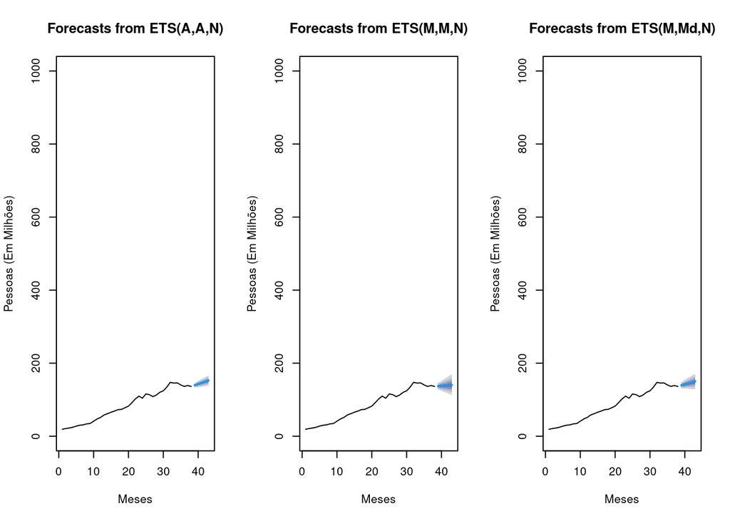

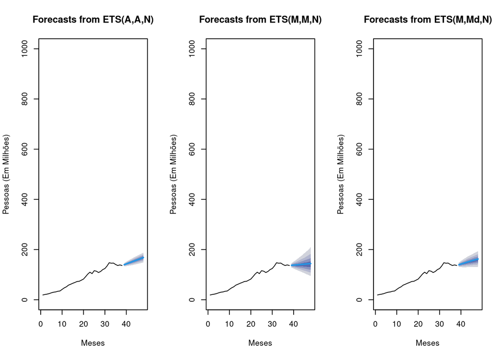

Por fim, quando é escolhida a configuração `damped = TRUE`, a tendência é amortecida, de maneira que a série da variável `pessoas.ets.MMdN.pred` é uma série com tendência multiplicativa amortecida, e sem sazonalidade. Assim, utilizando a tabela que foi apresentada em aula, tem-se as equações que definem esse modelo.

$$\begin{equation}
\begin{cases}
l_t = \alpha y_t + (1- \alpha)l_{t-1}b^\phi_{t-1}\\
b_t = \beta^*(\frac{l_t}{l_{t-1}}) + (1- \beta^*)b^\phi_{t-1}\\
\hat{y}_{t+h|t} = l_tb_t^{\phi_h}
\end{cases}
\end{equation}$$